# Stochastic SEIR

Graham Casey Gibson

4/2/2020

# Introduction

SIR/SEIR models are common epidemic modeling tools, with demonstrated success. The model is a non-linear differential equation given by.

$$\frac{dS}{dt} = - \beta * S * I / N$$
$$\frac{dE}{dt} = \beta * S * I / N - \sigma * E$$
$$\frac{dI}{dt} = \sigma * E - \gamma * I$$
$$\frac{dR}{dt} = \gamma * I$$

This model uniquely defines an epidemic curve, in fact we can simualte from the curve using the `deSolve` package in R to get a sense of what it looks like.

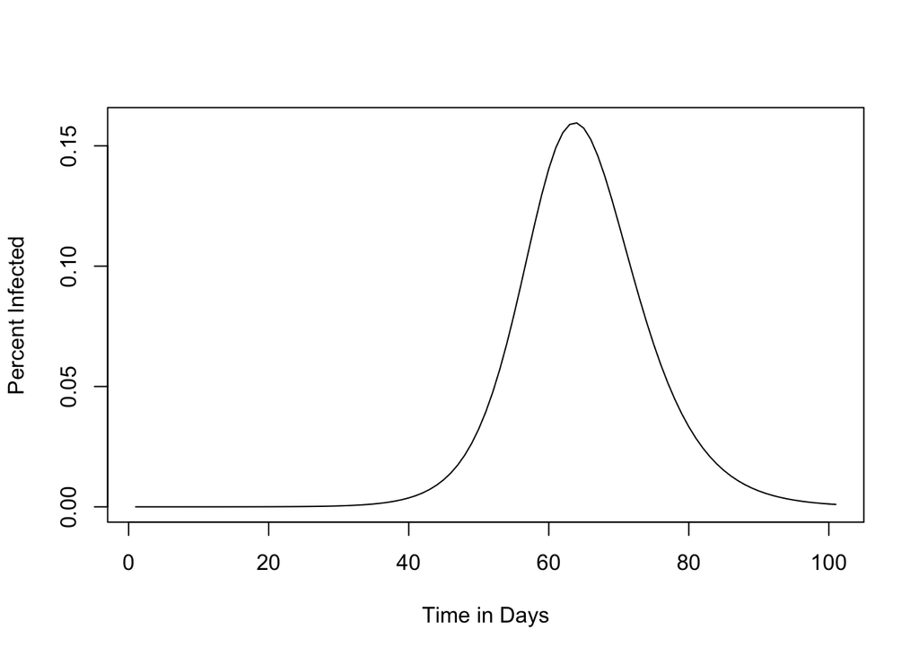

```r
library(deSolve)

## Create an SIR function
seir <- function(time, state, parameters) {

  with(as.list(c(state, parameters)), {

    dS <- -beta * S * I
    dE <-  beta * S * I - sigma * E
    dI <- sigma*E - gamma*I
    dR <-   gamma * I

    return(list(c(dS,dE, dI, dR)))
  })
}

### Set parameters
## Proportion in each compartment: Susceptible 0.999999, Infected 0.000001, Recovered 0
init       <- c(S = 1-1e-6, E=0,I = 1e-6, R = 0.0)
## beta: infection parameter; gamma: recovery parameter
parameters <- c(beta = .95, gamma = 1/3.5,sigma=1/3.7)
## Time frame
times      <- seq(0, 100, by = 1)

## Solve using ode (General Solver for Ordinary Differential Equations)
out <- ode(y = init, times = times, func = seir, parms = parameters)
## change to data frame
out <- as.data.frame(out)
plot(out$I,type='l',ylab='Percent Infected',xlab='Time in Days')
```

We can also think of this model as describing flow between compartments, where we parameterize the rate of flow. The rate of flow between the susceptible and exposed compartment is parameterized by $\beta$, and the rate of flow between the exposed compartment and the infected compartment by $\sigma$, and finally the rate of flow between the infected and recovered compartment by $\gamma$. This is graphically demonstrated below.

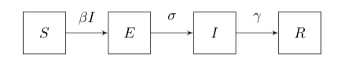

SEIR Comparmental Model

This model defines a smooth epidemic curve, which we rarely observe in practice. For instance, here is the current state of the COVID-19 epidemic in NY from `https://covidtracking.com/`.

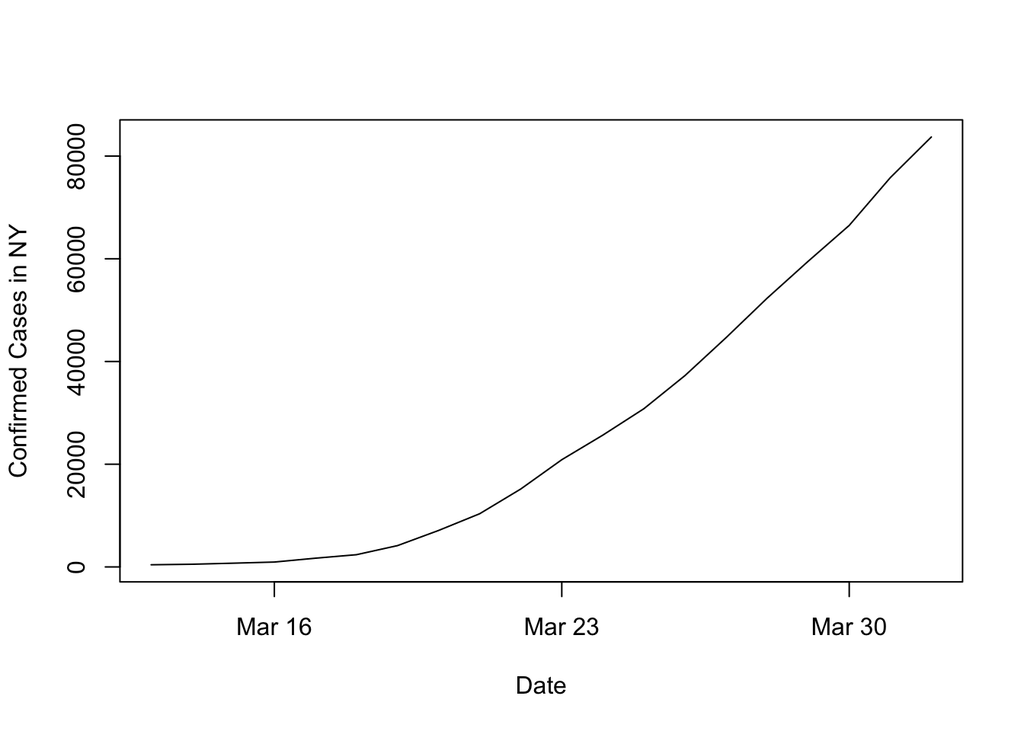

In order to allow for flexibility in the epidemic model, we instead model the epidmeic as a Bayesian compartmental model, allowing for stochasicity in the transitions between compartments. We define the following Bayesian epidemic model

$$C_t \sim N(I_t,\sigma_{C})$$
$$\Delta^{SE}_{t} \sim Beta(\sigma_{p_t}^{SE}*p_t^{SE},\sigma_{p_t}^{SE}*(1-p_t^{SE}))$$

$$\Delta^{EI}_{t} \sim Beta(\sigma_{p_t}^{EI}*p_t^{EI},\sigma_{p_t}^{EI}*(1-p_t^{EI}))$$
$$\Delta^{IR}_{t} \sim Beta(\sigma_{p_t}^{IR}*p_t^{IR},\sigma_{p_t}^{IR}*(1-p_t^{IR}))$$
$$p^{SE}_t= 1-e^{(-\beta*I_{t-1}/N)}$$
$$p_t^{EI}= 1-e^{-\sigma}$$
$$p_t^{IR}= 1-e^{-\gamma}$$
$$S_t = S_{t-1} - \Delta^{SE}_{t}*S_{t-1}$$
$$E_t = E_{t-1} + \Delta^{SE}_{t}*S_{t-1} -\Delta^{EI}_{t}*E_{t-1}$$
$$I_t = I_{t-1} + \Delta^{EI}_{t}*E_{t-1} - \Delta^{IR}_{t}*I_{t-1}$$
$$R_t = R_{t-1}+ \Delta^{IR}_{t}*I_{t-1}$$

This model imposes the compartmental transitions of the differential equation model, but without explicitly requiring a solution or approximation to the non-linear differential equation model. It also lets us parameterize our uncertainty about the epidemic through the transition varaince ($\sigma_{p_t}^{SE},\sigma_{p_t}^{EI},\sigma_{p_t}^{IR}$).

In what follows below we fit the model independently to each case count time series $C_{t,j}$ for state $j$.

```
## Please visit openintro.org for free statistics materials
```

```
## [1] "NY"
```

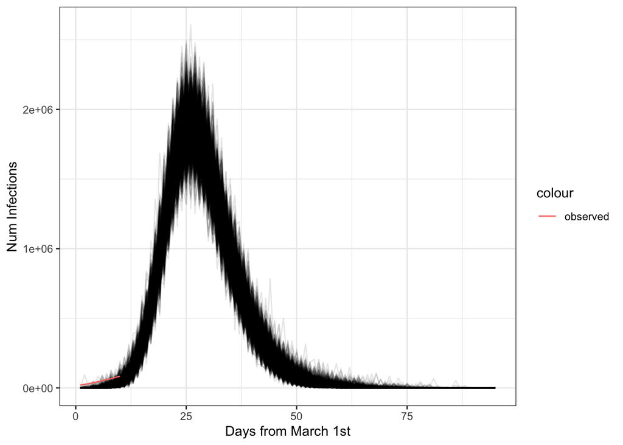

```
## [1] "CA"
```

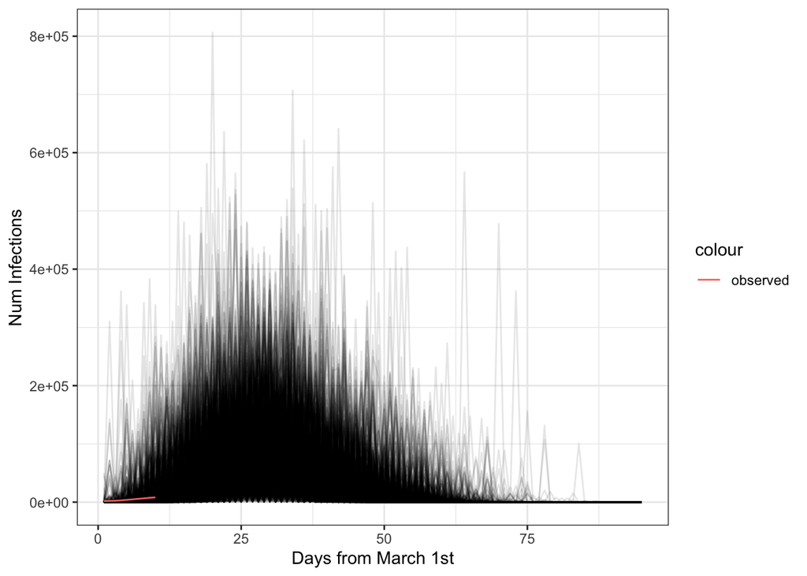

```
## [1] "MA"
```

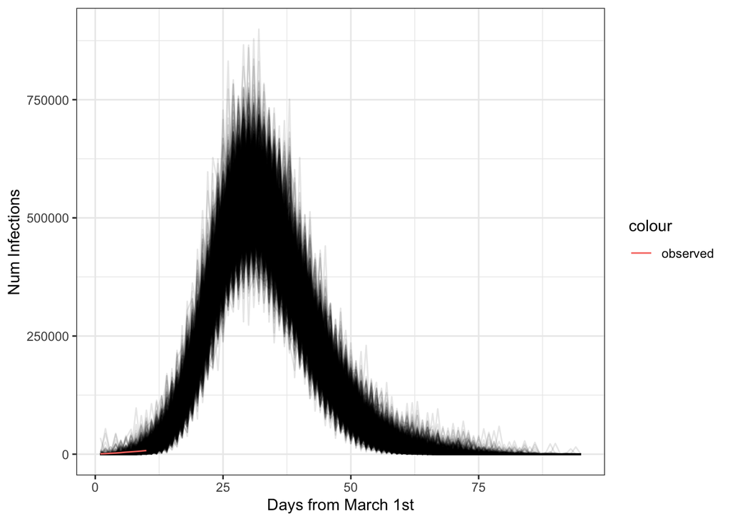

```r
location_idx <- 1
for (location in locations){
  print (location)
  print(ggplots[[location_idx]])
  location_idx <- location_idx + 1
}
```